# Inspection Outcome by Wood Decking Status

Priyanka Goel

2025-09-07

```r
library(readxl)
library(dplyr)
```

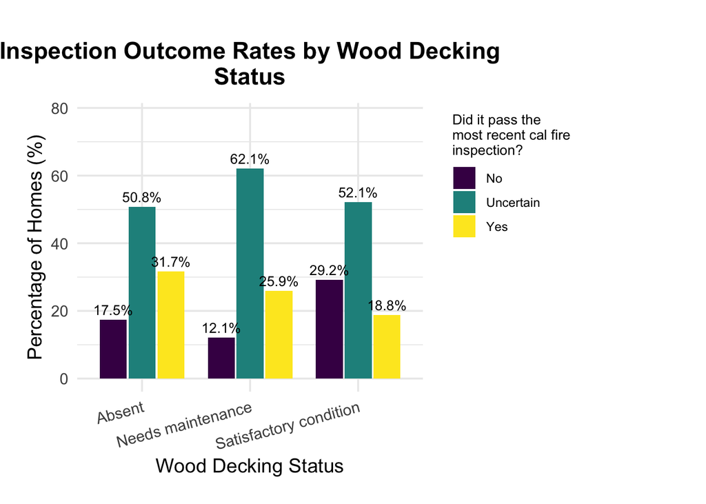

```r
library(ggplot2)
library(viridis)
library(stringr)

setwd("/Users/priyankagoel")
# Load data
df <- read_excel("CAMCOS and HIZ.xlsx", sheet = "Field data", skip = 1)
# Define column names
wood_decking_col <- "Deck/patio? (absent is that feature does not exist, satisfactory and maintenance is that the feature exists, NA is that feature not required e.g. concrete patio doesn't have deck boards. ) [Wood decking]"
inspection_col <- "Did it pass the most recent cal fire inspection?"

# Crosstab with percentages
crosstab <- table(df[[wood_decking_col]], df[[inspection_col]])
percentage_crosstab <- prop.table(crosstab, margin = 1) * 100
plot_data <- as.data.frame(percentage_crosstab)
colnames(plot_data) <- c("WoodDecking", "Inspection", "Percentage")

# Improve label order manually (optional, based on your image)
plot_data$WoodDecking <- factor(plot_data$WoodDecking,
  levels = c("Absent", "Needs maintenance", "Satisfactory condition")
)

# Plot
ggplot(plot_data, aes(x = WoodDecking, y = Percentage, fill = Inspection)) +
  geom_col(position = position_dodge(width = 0.8), width = 0.75) +
  geom_text(
    aes(label = sprintf("%.1f%%", Percentage)),
    position = position_dodge(width = 0.8),
    vjust = -0.5,
    size = 3.5
  ) +
  scale_fill_viridis_d() +
  labs(
    title = str_wrap("Inspection Outcome Rates by Wood Decking Status", 40),
    x = "Wood Decking Status",
    y = "Percentage of Homes (%)",
    fill = str_wrap(inspection_col, 25)
  ) +
  theme_minimal(base_size = 14) +
  theme(
    plot.title = element_text(face = "bold", hjust = 0.5, margin = margin(b = 10)),
    axis.text.x = element_text(angle = 15, hjust = 1),
    legend.position = "right",
    legend.justification = "top",
    legend.title = element_text(size = 10),
    legend.text = element_text(size = 9),
    plot.margin = margin(t = 30, r = 90, b = 20, l = 20)  # top-right-bottom-left
  ) +
  ylim(0, max(plot_data$Percentage) * 1.25)
```

**Insight 1: A “Satisfactory” Wood Deck is a Negative Sign**

This is the most critical and surprising finding from the chart.

The failure rate (No) for homes where a wood deck was present and in “Satisfactory condition” is 29.2%. This is the highest failure rate of the three categories. In contrast, the failure rate for homes where the wood deck “Needs maintenance” is only 12.1%.

The Insight: It tells us that a well-maintained wood deck does not guarantee a home will pass the inspection; in fact, it’s associated with a higher failure rate. This strongly suggests that homes are failing for other, more severe reasons that are completely unrelated to the deck’s condition.

**Insight 2: The “Pass” Rate is Relatively Stable**

The Insight: This reinforces the idea that the presence or condition of a wood deck is not a primary driver of passing the inspection either.

**Final Conclusion** The presence or condition of a wood deck is not a reliable standalone predictor of the Cal Fire inspection outcome. The relationship is complex and heavily influenced by other factors. A home with a perfect wood deck can still fail, and a home with a wood deck needing maintenance can still pass, depending on the overall condition of the property.